# Multivariate Analysis Of Variance

Data science nuggets

## Introduction

- my previous blog talked about comparing two means using `T.TEST` and as well as comparing more than 2 means with `ANOVA`

### RECAP ANOVA

- for this one we said consider yourself having having `one dependent` variable and `one or more independent` variables which are factors

| day 5 | day 20 | day 35 |
| --- | --- | --- |
| 10 | 15 | 35 |
| 15 | 30 | 40 |
| 25 | 20 | 50 |
| 15 | 15 | 43 |
| 20 | 23 | 45 |
| 18 | 20 | 40 |
| 103 | 123 | 253 |

- the above dataset as it stands might look a bit weird but once we change it to long format we get

```r
library(tidyverse)
df<-tribble(~DAY_5 ,~DAY_20,~DAY_35,
    10, 15, 35,
    15, 30, 40,
    25, 20, 50,
    15, 15, 43,
    20, 23, 45,
    18, 20, 40)
df |>
  gather("day","time") |>
  knitr::kable()
```

| day | time |
| --- | --- |
| DAY_5 | 10 |
| DAY_5 | 15 |
| DAY_5 | 25 |
| DAY_5 | 15 |
| DAY_5 | 20 |
| DAY_5 | 18 |
| DAY_20 | 15 |
| DAY_20 | 30 |
| DAY_20 | 20 |
| DAY_20 | 15 |
| DAY_20 | 23 |
| DAY_20 | 20 |
| DAY_35 | 35 |
| DAY_35 | 40 |
| DAY_35 | 50 |
| DAY_35 | 43 |
| DAY_35 | 45 |
| DAY_35 | 40 |

- now we have `time` as the `dependent` variable and `day` as the `independent` variable
- so we generally assume the following assumptions

### assumptions

1. **Univariate Normal distribution**  
   The residuals of ANOVA model can once again be visualised in the normal QQplot. If the residuals lie linearly on the 1:1 line of the QQplot, they can be considered as normally distributed. If not, the ANOVA results cannot be interpreted.
2. **Homoscedasticity**  
   To be valid, ANOVA must be performed on models with homogeneous variance of the residuals. This homoscedasticity can be verified using either the residuals vs fitted plot or the scale-location plot of the diagnostic plots.

### Univariate Normal

Random variable $X$ is distributed $X \sim N(\mu, \sigma^2)$ if

$$f(X)=\frac{{1}}{{\sigma
\sqrt{{2\pi}}}}e^{-.5(\frac{{x-\mu}}{{\sigma}})^2}$$
.

## MANOVA

### Multivariate Normal Distribution

**Multivariate Normal Distribution**

Let $\mathbf{y}$ be a multivariate normal (MVN) random variable with mean $\mu$ and variance $\mathbf{\Sigma}$. Then the density of $\mathbf{y}$ is

$$f(\mathbf{y}) = \frac{1}{(2\pi)^{p/2}|\mathbf{\Sigma}|^{1/2}}
\exp(-\frac{1}{2} \mathbf{(y-\mu)'\Sigma^{-1}(y-\mu)} )$$

$\mathbf{y} \sim N_p(\mu, \mathbf{\Sigma})$

### Properties of MVN

- Let $\mathbf{A}_{r \times p}$ be a fixed matrix. Then $\mathbf{Ay} \sim N_r (\mathbf{A \mu, A \Sigma A'})$ . $r \le p$ and all rows of $\mathbf{A}$ must be linearly independent to guarantee that $\mathbf{A \Sigma A}'$ is non-singular.
- Let $\mathbf{G}$ be a matrix such that $\mathbf{\Sigma}^{-1} = \mathbf{GG}'$. Then $\mathbf{G'y} \sim N_p(\mathbf{G' \mu, I})$ and $\mathbf{G'(y-\mu)} \sim N_p (0,\mathbf{I})$
- Any fixed linear combination of $y_1,...,y_p$ (say $\mathbf{c'y}$) follows $\mathbf{c'y} \sim N_1 (\mathbf{c' \mu, c' \Sigma c})$

## Multivariate Analysis of Variance(MANOVA)

**One-way MANOVA**

- Compare treatment means for h different populations
- now we have more than one `dependent` variables

Population 1: $\mathbf{y}_{11}, \mathbf{y}_{12}, \dots, \mathbf{y}_{1n_1} \sim idd N_p (\mathbf{\mu}_1, \mathbf{\Sigma})$

$\vdots$

Population h: $\mathbf{y}_{h1}, \mathbf{y}_{h2}, \dots, \mathbf{y}_{hn_h} \sim idd N_p (\mathbf{\mu}_h, \mathbf{\Sigma})$

- Using the `ANOVA` example , lets say we now have other than `time` we could also have the `weight` and the `height` of the the `lab rats` at those days.

**Assumptions**

1. Independent random samples from $h$ different populations
2. Common covariance matrices
3. Each population is multivariate **normal**

Calculate the summary statistics $\mathbf{\bar{y}}_i, \mathbf{S}$ and the pooled estimate of the covariance matrix $\mathbf{S}$

Similar to the univariate one-way ANVOA, we can use the effects model formulation $\mathbf{\mu}_i = \mathbf{\mu} + \mathbf{\tau}_i$, where

- $\mathbf{\mu}_i$ is the population mean for population i
- $\mathbf{\mu}$ is the overall mean effect
- $\mathbf{\tau}_i$ is the treatment effect of the i-th treatment.

For the one-way model: $\mathbf{y}_{ij} = \mu + \tau_i + \epsilon_{ij}$ for $i = 1,..,h; j = 1,..., n_i$ and $\epsilon_{ij} \sim N_p(\mathbf{0, \Sigma})$

However, the above model is over-parameterized (i.e., infinite number of ways to define $\mathbf{\mu}$ and the $\mathbf{\tau}_i$’s such that they add up to $\mu_i$. Thus we can constrain by having

$$\sum_{i=1}^h n_i \tau_i = 0$$

or

$$\mathbf{\tau}_h = 0$$

The observational equivalent of the effects model is

$$\begin{aligned}
\mathbf{y}_{ij} &= \mathbf{\bar{y}} + (\mathbf{\bar{y}}_i -
\mathbf{\bar{y}}) + (\mathbf{y}_{ij} - \mathbf{\bar{y}}_i) \\
&= \text{overall sample mean} + \text{treatement effect} +
\text{residual} \text{ (under univariate ANOVA)}
\end{aligned}$$

After manipulation

$$\sum_{i = 1}^h \sum_{j = 1}^{n_i} (\mathbf{\bar{y}}_{ij} -
\mathbf{\bar{y}})(\mathbf{\bar{y}}_{ij} - \mathbf{\bar{y}})' =
\sum_{i = 1}^h n_i (\mathbf{\bar{y}}_i -
\mathbf{\bar{y}})(\mathbf{\bar{y}}_i - \mathbf{\bar{y}})' + \\
\sum_{i=1}^h \sum_{j = 1}^{n_i} (\mathbf{\bar{y}}_{ij} -
\mathbf{\bar{y}})(\mathbf{\bar{y}}_{ij} - \mathbf{\bar{y}}_i)'$$

LHS = Total corrected sums of squares and cross products (SSCP) matrix

RHS =

- 1st term = Treatment (or between subjects) sum of squares and cross product matrix (denoted H;B)
- 2nd term = residual (or within subject) SSCP matrix denoted (E;W)

Note:

$$\mathbf{E} = (n_1 - 1)\mathbf{S}_1 + ... + (n_h -1) \mathbf{S}_h =
(n-h) \mathbf{S}$$

MANOVA table

MONOVA table

| Source | SSCP | df |
| --- | --- | --- |
| Treatment | $\mathbf{H}$ | $h -1$ |
| Residual (error) | $\mathbf{E}$ | $\sum_{i= 1}^h n_i - h$ |
| Total Corrected | $\mathbf{H + E}$ | $\sum_{i=1}^h n_i -1$ |

$$H_0: \tau_1 = \tau_2 = \dots = \tau_h = \mathbf{0}$$

We consider the relative “sizes” of $\mathbf{E}$ and $\mathbf{H+E}$

Wilk’s Lambda

Define Wilk’s Lambda

$$\Lambda^* = \frac{|\mathbf{E}|}{|\mathbf{H+E}|}$$

Properties:

1. Wilk’s Lambda is equivalent to the F-statistic in the univariate case
2. The exact distribution of $\Lambda^*$ can be determined for especial cases.
3. For large sample sizes, reject $H_0$ if

$$-(\sum_{i=1}^h n_i - 1 - \frac{p+h}{2}) \log(\Lambda^*) >
\chi^2_{(1-\alpha, p(h-1))}$$

## MANOVA IN R

> suppose for the labrats , we now give the rats different drugs now and test them on conditions `y1,y2,y3 and y4`

```r
library(tidyverse)
## Read in Data
lab <- read.table("images/labrats.dat")
names(lab) <- c("drug", "y1", "y2", "y3", "y4")
## Create a subject ID nested within drug

lab <- lab %>%
    group_by(drug) %>%
    mutate(subject = row_number()) %>%
    ungroup()
str(lab)
```

```
#> tibble [24 x 6] (S3: tbl_df/tbl/data.frame)
#>  $ drug   : chr [1:24] "ax23" "ax23" "ax23" "ax23" ...
#>  $ y1     : int [1:24] 72 78 71 72 66 74 62 69 85 82 ...
#>  $ y2     : int [1:24] 86 83 82 83 79 83 73 75 86 86 ...
#>  $ y3     : int [1:24] 81 88 81 83 77 84 78 76 83 80 ...
#>  $ y4     : int [1:24] 77 82 75 69 66 77 70 70 80 84 ...
#>  $ subject: int [1:24] 1 2 3 4 5 6 7 8 1 2 ...
```

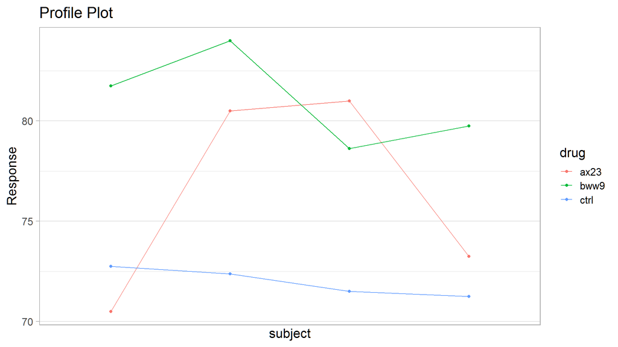

```r
## Create means summary for profile plot, pivot longer for plotting with ggplot
lab_means <- lab %>%
    group_by(drug) %>%
    summarize_at(vars(starts_with("y")), mean) %>%
    ungroup() %>%
    pivot_longer(-drug, names_to = "subject", values_to = "mean") %>%
    mutate(subject = as.numeric(as.factor(subject)))
gg_profile <- ggplot(lab_means, aes(x = subject, y = mean)) +
    geom_line(aes(col = drug)) +
    geom_point(aes(col = drug)) +
    ggtitle("Profile Plot") +
    scale_y_continuous(name = "Response") +
    scale_x_discrete(name = "subject")
gg_profile
```

### visualise boxplots

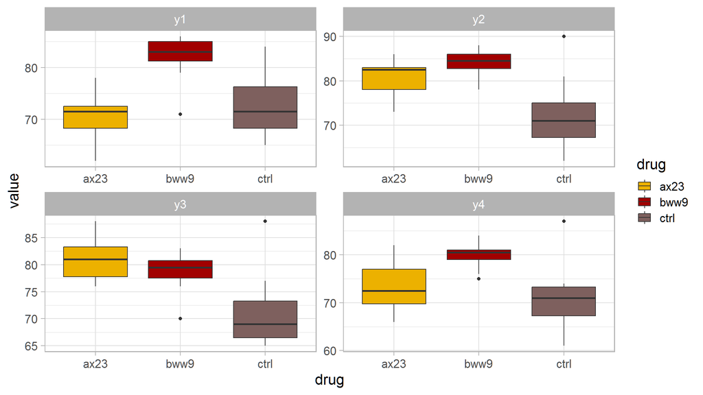

```r
lab |>
  select(-subject) |>
  gather("response","value",-drug) |>
  ggplot(aes(x=drug,y=value,fill=drug))+
  geom_boxplot()+
  facet_wrap(~response,scales="free")+
  tvthemes::scale_fill_avatar()
```

## Fitting A manova in R

### Using `manova()`

```r
lm_mod <- manova(cbind(y1, y2, y3, y4) ~ drug, data = lab)
summary(lm_mod)
```

```
#>           Df Pillai approx F num Df den Df    Pr(>F)
#> drug       2 1.2835   8.5081      8     38 1.501e-06 ***
#> Residuals 21
#> ---
#> Signif. codes:  0 '***' 0.001 '**' 0.01 '*' 0.05 '.' 0.1 ' ' 1
```

## look to see which ones differ

```r
summary.aov(lm_mod)
```

```
#>  Response y1 :
#>             Df Sum Sq Mean Sq F value   Pr(>F)
#> drug         2    567 283.500  9.2878 0.001289 **
#> Residuals   21    641  30.524
#> ---
#> Signif. codes:  0 '***' 0.001 '**' 0.01 '*' 0.05 '.' 0.1 ' ' 1
#>
#>  Response y2 :
#>             Df Sum Sq Mean Sq F value   Pr(>F)
#> drug         2 569.08 284.542  7.2528 0.004029 **
#> Residuals   21 823.88  39.232
#> ---
#> Signif. codes:  0 '***' 0.001 '**' 0.01 '*' 0.05 '.' 0.1 ' ' 1
#>
#>  Response y3 :
#>             Df Sum Sq Mean Sq F value   Pr(>F)
#> drug         2 391.08 195.542  6.2609 0.007368 **
#> Residuals   21 655.88  31.232
#> ---
#> Signif. codes:  0 '***' 0.001 '**' 0.01 '*' 0.05 '.' 0.1 ' ' 1
#>
#>  Response y4 :
#>             Df Sum Sq Mean Sq F value  Pr(>F)
#> drug         2  316.0 158.000  4.9192 0.01769 *
#> Residuals   21  674.5  32.119
#> ---
#> Signif. codes:  0 '***' 0.001 '**' 0.01 '*' 0.05 '.' 0.1 ' ' 1
```

### using `lm`

```r
## Fit model
lab_mod <- lm(cbind(y1, y2, y3, y4) ~ drug, data = lab)
man_fit <- car::Anova(lab_mod)
summary(man_fit)
```

```
#>
#> Type II MANOVA Tests:
#>
#> Sum of squares and products for error:
#>        y1      y2      y3     y4
#> y1 641.00 601.750 535.250 426.00
#> y2 601.75 823.875 615.500 534.25
#> y3 535.25 615.500 655.875 555.25
#> y4 426.00 534.250 555.250 674.50
#>
#> ------------------------------------------
#>
#> Term: drug
#>
#> Sum of squares and products for the hypothesis:
#>        y1       y2       y3    y4
#> y1 567.00 335.2500  42.7500 387.0
#> y2 335.25 569.0833 404.5417 367.5
#> y3  42.75 404.5417 391.0833 171.0
#> y4 387.00 367.5000 171.0000 316.0
#>
#> Multivariate Tests: drug
#>                  Df test stat  approx F num Df den Df     Pr(>F)
#> Pillai            2  1.283456  8.508082      8     38 1.5010e-06 ***
#> Wilks             2  0.079007 11.509581      8     36 6.3081e-08 ***
#> Hotelling-Lawley  2  7.069384 15.022441      8     34 3.9048e-09 ***
#> Roy               2  6.346509 30.145916      4     19 5.4493e-08 ***
#> ---
#> Signif. codes:  0 '***' 0.001 '**' 0.01 '*' 0.05 '.' 0.1 ' ' 1
```

> the output contains more information regarding the methods used